# Reporte del capital burocrático en la contienda de 1824 en Costa Rica

n0dn | The linked Data

analisis

politica

capital burocrático

Costa Rica

Siglo XIX

Análisis del capital burocrático de los candidatos presidenciales de Costa Rica en 1824.

Autor/a

Dr. Norberto Bustos

Fecha de publicación

4 de mayo de 2026

## 1 Introducción

El presente reporte analiza el capital burocrático de los contendientes a las elecciones presidenciales de Costa Rica en el año 1824, desde una perspectiva que combina la ciencia de datos con la teoría política estructural. El estudio toma como unidad de análisis al agente individual y examina cómo los candidatos acumulan y utilizan diferentes formas de capital político a lo largo de sus trayectorias. La metodología propuesta se fundamenta en los aportes teóricos de Nicos Poulantzas y Bob Jessop sobre el Aparato de Estado (ApE), y operacionaliza el concepto de capital burocrático (kb) a partir de la suma ponderada de los cargos directivos ocupados dentro y fuera del Estado, considerando su jerarquía, duración y capacidad de influencia. Para evaluar la eficiencia de esta acumulación se construye el Índice de Rendimiento del Capital Burocrático por Edad adulta (IRBE) , que combina la eficiencia burocrática, la eficiencia electoral y un factor de éxito diferenciado. De esta forma, el reporte permite identificar, medir y comparar el capital político de cada aspirante a la presidencia de Costa Rica en el período comprendido entre 1824 y 2026.

## 2 Metodología

El estudio parte de una metodología particular para el análisis del capital político desde un enfoque estructural. El capital político puede entenderse como una forma específica de capital social que representa un conjunto de activos relacionales, simbólicos y de dominación —como el prestigio, los cargos directivos, los recursos financieros o militares— acumulados por actores o redes con el propósito de ejercer influencia o dominación dentro del sistema político. En este sentido, el **ApE** se define como el conjunto organizado de instituciones políticas, jurídicas y coercitivas que estructuran el ejercicio del poder estatal y aseguran la reproducción de las relaciones sociales de producción, manteniendo al mismo tiempo una relativa autonomía frente a las clases sociales.

En América Latina, tras las guerras de independencia la configuración de las clases dirigentes parten de estractos arcáico y atípicos en comparaión con la coformación de la burguesía europea del mismo periodo (Ribeiro, 1977). La procedencia de las clases dominantes procede de un contexto colonial-exclavista y que evolucionaría durante el siglo XIX en un empresariado mercantil y que hasta el primer tercio del siglo XX avanzaría hacia una burgesía neocolonial y dependiente, los cuales retrasaron la creación de un capitalismo autónomo[Basave Kunhardt (1997)](Collier & Sater, 1999). La mezcla entre las clases dominantes con las clases dirigentes, es decir con las redes de burócratas, militares, funcionarios públicos [Beyhaut & Beyhaut (1985)](Balmori et al., 1990)(Bambirra, 1978) evolucionó durante el último siglo y medio en la conformación de los tecnócratas, líderes populistas y civiles que han dominado la arena política latinoamericana hasta la actualidad a partir de su dominio en los diferentes sectores que componen el aparato de Estado, con los cuales, van acumulando prestigio y poder político.

En este marco conceptual, definimos el **capital burocrático** (*kb*) como un componente del capital político que, tanto en su dimensión estratégica como estructural, adquiere relevancia por su centralidad dentro del ApE. Este planteamiento parte de la concepción del Estado desarrollada por Nicos Poulantzas, quien sostiene que el Estado no es un conjunto neutral de instituciones, sino una estructura institucional que organiza y garantiza la reproducción del poder político de las clases dominantes dentro de una formación social capitalista(Poulantzas, 1991).

A partir de esta perspectiva, Bob Jessop define el ApE como el conjunto de instituciones, organizaciones y recursos administrativos a través de los cuales se ejerce la autoridad política y se implementan las decisiones gubernamentales dentro de un territorio determinado (Jessop, 2016). Jessop advierte que, además de las estructuras institucionales formales —como el gobierno, la administración pública, el sistema judicial o las fuerzas armadas— que permiten formular, ejecutar y hacer cumplir las políticas públicas, existen también otras fuerzas no formales que influyen en la reproducción del Estado capitalista. Entre ellas se encuentran grandes empresas, monopolios, grupos paramilitares o estructuras de poder económico territorial como los latifundios. Desde su **enfoque estratégico-relacional del Estado**, Jessop sostiene que el aparato estatal constituye una configuración institucional que ofrece oportunidades y restricciones diferenciadas para los actores sociales y políticos, dependiendo de la correlación de fuerzas existente.

Partiendo de esta concepción relacional —basada en los aportes teóricos de Poulantzas y Jessop— se desarrolla la metodología propuesta para el estudio del capital burocrático. Desde esta perspectiva, el actor que acumula mayor capital burocrático adquiere la capacidad instrumental de movilizar recursos y vínculos institucionales como resultado de su trayectoria política. Esta capacidad se deriva de su posibilidad de establecer relaciones con actores históricamente relevantes, dirigir instituciones públicas y articular estos recursos con otros activos externos al aparato estatal para consolidar su poder individual o grupal. En este sentido, el *kb* es el resultado de la acumulación de competencias, experiencia y posiciones en cargos directivos dentro y fuera del ApE, que los actores adquieren a lo largo de su trayectoria política en la competencia por convertirse en agentes dominantes dentro de una red política.

Desde una perspectiva operativa, el capital burocrático (*kb*) se mide a partir de la trayectoria institucional de los actores, considerando variables como:

1. Número y nivel jerárquico de los cargos ocupados dentro del ApE;
2. Duración o permanencia en dichas posiciones;
3. Centralidad estratégica de las instituciones dirigidas; y
4. Capacidad de articulación con redes políticas o económicas externas al Estado.

En conjunto, estas dimensiones permiten estimar el grado de acumulación de capital burocrático de un actor y su posición relativa dentro de la estructura de poder estatal.

Finalmente, la organización del ApE puede describirse por su topología como una compleja red jerárquica ((Barrat et al., 2004); (Ravasz & Barabasi, 2002); (Barabási & Albert, 1999)). Esta estructura se caracteriza por la planificación de tareas administrativas en tres niveles principales —ejecutivo, organizacional y operativo—, lo que implica que pequeños grupos de actores se articulen jerárquicamente en distintos niveles de decisión. A partir de estos niveles se desprenden grupos progresivamente más amplios, al tiempo que la estructura mantiene una topología libre de escala y un grado específico de agrupamiento, rasgos característicos de los sistemas organizacionales complejos.

### 2.1 Cálculo del kb según los niveles en el aparato de Estado

Partiendo de este principio que caracteriza a las redes jerárquicas, les fueron asignados un valor por cada nivel jerárquico dentro del ApE, asumiendo que la posición de Jefe de Estado o Presidente es el nivel más alto dentro del mismo. Encontramos trece niveles jerárquicos partiendo del supuesto anteriormente señalado. A su vez, cada posición directiva cuenta con un valor que va del 5 al 10, donde:

- **10** — Ministro o Secretario de Estado
- **9** — Subsecretaría
- **8** — Dirección General
- **7** — Dirección de Área
- **6** — Dirección
- **5** — Subdirección

Los niveles burocráticos se dividen en dos dimensiones: **a) Dentro** y, **b) Fuera del ApE**.

Asimismo, identificamos que se pueden agrupar diferentes cargos en torno a **clases** en función de su capacidad de movilización del ApE.

Donde:

- *para* son cargos que tienen la facultad de gobernar regiones, modificar las leyes, limitar el presupuesto, movilizar al ejército y sancionar a partir de la normativa aplicable, es decir, son el contrapeso institucional o paralelo a la clase **intra** y viceversa.

- *sub* son cargos que se encuentran con un relativo grado de influencia local ya sea como gobernantes de alcaldías o municipios, así como de organizaciones políticas autónomas como los partidos o movimientos políticos formales, pero cuyas decisiones se encuentran subordinadas a niveles jerárquicos superiores.

- *exa* son cargos que se consideran fuera del ApE pero que guardan una relación indirecta aunque autónoma tales como las empresas o banca privada, asociaciones civiles, educativas, sindicatos o gremios.

- *ana* son posiciones directivas fuera del ApE y contrarias al mantenimiento del mismo, como organizaciones insurgentes o revolucionarios, paramilitares, guerrilleros, entre otros.

Tabla 1: Clasificación de agentes políticos y su relación con el Estado

| Posición en torno al Estado | Clase | Descripción | Cargos | Factor de influencia Burocrática (F) |
| --- | --- | --- | --- | --- |
| Dentro | Intra | Contribuye directamente con el Jefe de Estado y de Gobierno de la República. | Presidente, Vicepresidente, Ministros, Embajadores, Directivos de empresas paraestatales | 13-11 |
|  | Para | Forman parte del contrapeso institucional al poder Ejecutivo. | Gobernadores, Diputados, Senadores, Magistrados, Militares. | 10-7 |
|  | Sub | Cargos de gobierno o legislatura a nivel local o municipal, dependientes de un gobierno regional. | Alcaldes, líderes de partidos políticos. | 6-5 |
| Fuera | Exa | Fuera del aparato de Estado; poseen influencia por grupos de interés y presión. | Empresarios, banqueros, gremios industriales, líderes sociales, líderes sindicales. | 4-3 |
|  | Ana | Grupos contrarios al aparato de Estado que persiguen cambios radicales (lucha armada). | Movimientos insurgentes, revolucionarios o grupos paramilitares, religiosos. | 2-1 |

Al final, para calcular el valor del **kb** que mide la acumulación de cargos directivos dentro y fuera del parato de Estado mediante la suma ponderada de cargos directivos dentro ($d$) y fuera ($f$) del aparato estatal, elevados al factor de influencia ($F$) correspondiente a cada nivel jerárquico:

$$\tag{1} k_b = \sum_{i=1}^n (d_i^F + f_i^F) $$

Donde:  
- *d* es la suma de cargos **dentro** del Estado en nivel *i*;  
- *f* es la suma de cargos **fuera** del Estado en nivel *i*;  
- *F* es el Factor de influencia burocrática

### 2.2 Índice de Rendimiento del Capital Burocrático por Edad adulta

¿Cómo determinar si la trayectoria poliítica de un candidato ha sido más provechosa que otra para convertir la acumulación del capital burocrático en éxito electoral? Para ello debemos considerar cuatro factores.

$$\tag{4} \text{irbe}_i = e_b \times e_e \times \lambda$$

El *IRBE* estima la **eficiencia relativa** con la que un candidato transforma su capital burocrático acumulado en rendimiento electoral considerando su **tiempo efectivo de vida política adulta**.

La interpretación del IRBE versa en torno a tres probables casos:

Caso 1: IRBE alto por eficiencia_burocratica alta. El candidato es un “constructor de Estado”, con mucha experiencia, pero quizás no tan popular.

Caso 2: IRBE alto por eficiencia_electoral alta. El candidato es un “outsider” con poco KB pero enorme arrastre popular (caso típico de populismo).

Caso 3: Ambos altos. El candidato ideal (hegemónico).

## 3 Datos generales de los candidatos

| Candidato | Edad | Entidad de nacimiento | Alianza o Partido | Votos obtenidos | Resultado | Capital burocrático |
| --- | --- | --- | --- | --- | --- | --- |
| Juan Mora Fernandez | 40 | San José | Liberal | 84% | Ganador | 577 |
| José Rafael de Gallegos y Alvarado | 40 | Cartago | Liberal | 15% | Perdedor | 295 |

Perfil de los candidatos y distribución geográfica

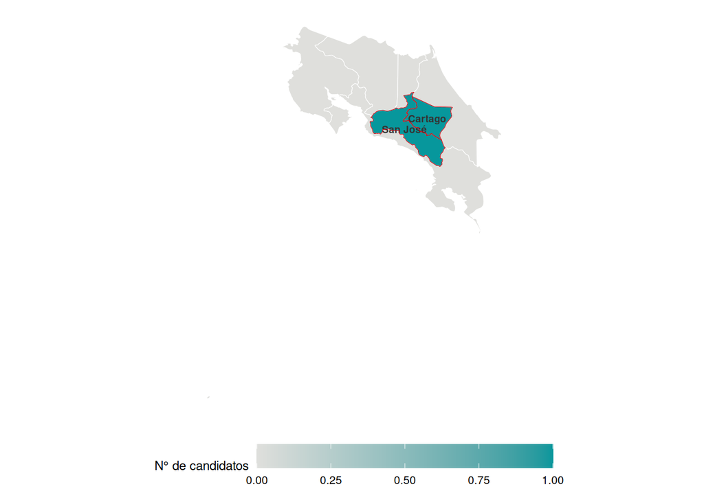

Perfil de los candidatos y distribución geográfica

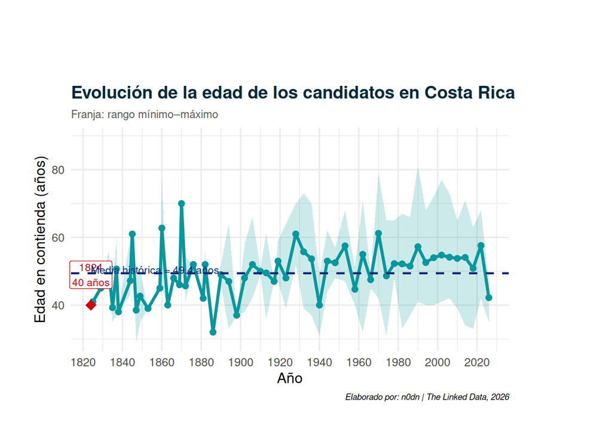

Con los datos generales de los candidatos daremos inicio al análisis del capital burocrático y de la eficacia burocrática y electoral a partir del rendimiento del tiempo de sus edad adulta para acumularlo e invertirlo en su carrera para la presidencia de Costa Rica.

## 4 Distribución del capital burocrático por candidato

Como señalamos al inicio, el capital burocrático se conforma por la acumulación de cargos directivos dentro y fuera del aparato de Estado durante toda la trayectoria política de cada candidato hasta el momento de la contienda presidencial. Para ello, analizamos cuántos cargos acumulan en las diferentes instituciones, organismos y eventos en los cuales juegan un papel protagónico o directivo. En el siguiente gráfico se deslosa el la acumulación del *kb* de cada candidato por tipo de institución. La línea punteada indica la **media de la contienda** (436 kb). Los colores azules refieren a aquellas instituciones con mayor cercanía con la presidencia de la república, es decir, con la conducción del aparato burocrático, los morados se refieren a las instituciones que dependen y en ocasiones, inciden, con las instituciones del estado. En cambio, las instituciones más cercanas al color rojo y amarillo, representan a aquellos cargos fuera del ApE y cuyas decisiones organizativas son autónomas al mismo.

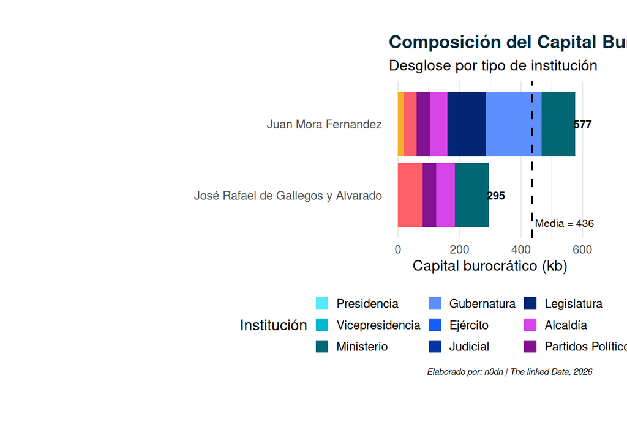

Composición del capital burocrático por candidato — Costa Rica 1824

### 4.1 El ganador de la contienda

El candidato **Juan Mora Fernandez** del partido o alianza **Liberal** resultó ganador de la contienda presidencial de Costa Rica en 1824 con un **84%** de los votos.

Su capital burocrático acumulado es de **577 kb**, lo que representa una trayectoria institucional superior a la media de la contienda (436 kb). El perfil de Juan Mora Fernandez se clasifica como **Gobierno subnacional / Legislativo**, indicando que su trayectoria tiene características particulares.

El **19.1%** de su capital burocrático se concentra en posiciones de alta dirección estatal: Presidencia, Vicepresidencia y Ministerios. Desglosado, el 0% corresponde a la **Presidencia**, el 0% a la **Vicepresidencia** y el 19.1% a **Ministerios de Estado**. Los cargos que componen el 80% de su *kb* son: Gubernatura, Legislatura, Ministerio.

### 4.2 Los candidatos perdedores

En esta contienda participaron **1 candidatos perdedores**, acumulando en conjunto **295 kb**, con un promedio de **295 kb** por candidato.

#### 4.2.2 Análisis agregado de los perdedores

En promedio, los candidatos perdedores concentran su capital burocrático de la siguiente manera:

- **Alta dirección estatal** (Presidencia, Vicepresidencia, Ministerios): 37.3%
- **Gobierno subnacional y legislativo** (Gobernaturas, Legislaturas, Cortes Supremas): 0%
- **Ámbito local y partidista** (Alcaldías y Partidos Políticos): 35.6%
- **Sector externo** (Empresas, Sociedad Civil, Movimientos de Rebelión): 27.1%
- **Poder militar** (Ejército): 0%

Esta distribución sugiere que los perdedores tienden a tener una mayor proporción de experiencia en el núcleo del poder ejecutivo nacional, aunque no lograron capitalizarla electoralmente.

## 5 Clases de capital burocrático (Dentro y Fuera del ApE)

Las clases de capital burocrático permiten identificar cuánto de ese capital proviene de organizaciones dentro y fuera del *ApE*. Históricamente, el **87.24%** del capital burocrático de los candidatos presidenciales de **Costa Rica** se genera dentro del ApE, mientras que el **12.76%** se genera fuera del mismo.

En el caso de la presente contienda, el **81.24%** correspondió a cargos dentro del ApE y el **18.76%** a cargos fuera de él, lo cual indica **menor control del ApE** en comparación con el promedio histórico. En contraste, el capital fuera del ApE indica **mayor presencia en organizaciones fuera del ApE** respecto al promedio histórico del país.

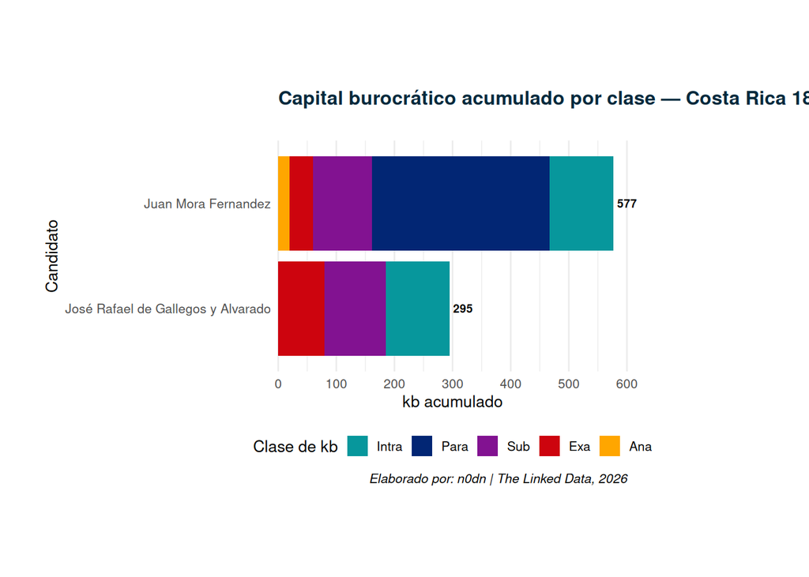

En cuanto al capital burocrático **dentro** del ApE, el candidato con mayor acumulación es **Juan Mora Fernandez** con **517 kb**, siendo su componente más destacado el nivel **Para** con **306 kb**.

Respecto al capital burocrático **fuera** del ApE, el candidato con mayor acumulación es **José Rafael de Gallegos y Alvarado** con **80 kb**, siendo su componente predominante el nivel **Exa** con **80 kb**.

### 5.1 Top 3 de la contienda

A continuación analizamos a los candidatos con mayor capital burocrático y comparamos la suma de su *kb* con el resto.

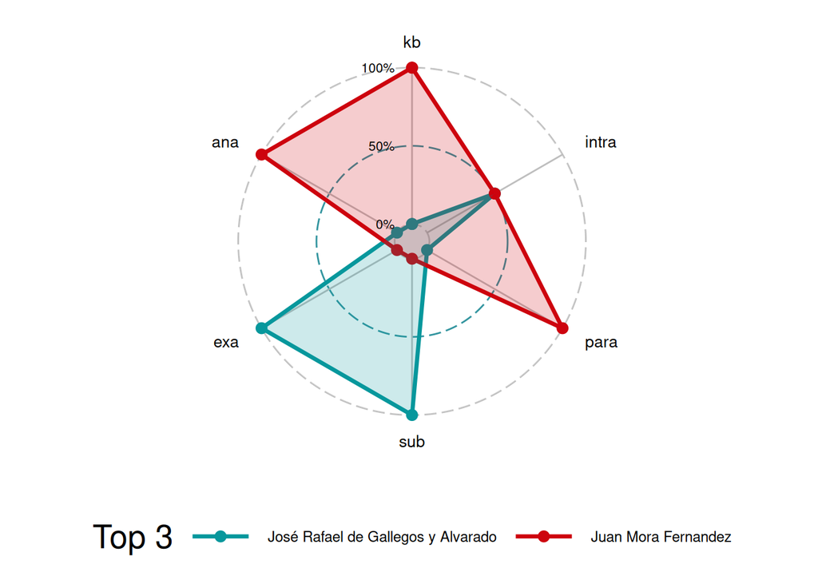

Los tres candidatos líderes concentran el **100%** del capital burocrático total de la contienda (HHI = **0.5523**), lo que refleja una alta concentración de experiencia directiva entre los contendientes.

La brecha entre el primer y segundo lugar es de **282 kb** (**48.9%**), lo que representa una ventaja sustancial del líder.

El candidato ganador ocupa la **posición 1** del ranking de capital burocrático, con un kb de **577**, equivalente a **1.32 veces la media** de la contienda.

## 6 Comparación con la media histórica

El capital burocrático no es estático: se acumula, se dispersa y refleja los ciclos políticos de cada país. El siguiente gráfico muestra la evolución del **kb promedio por contienda** en **Costa Rica** desde 1824 hasta 2026, junto con el rango entre el candidato con mayor y menor kb en cada elección. El punto rojo indica la contienda seleccionada (**1824**).

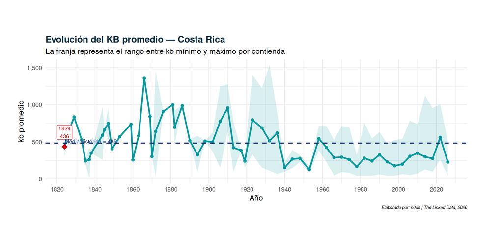

Evolución histórica del KB promedio — Costa Rica

Históricamente, los ganadores en Costa Rica acumulan en promedio **579 kb**, frente a **300 kb** de los perdedores, lo que representa una ventaja de **1.93 puntos**. El mayor kb registrado en la historia del país corresponde a **Romualdo Ricardo Jiménez Oreamuno** en **1932** con **1,537 kb**.

## 7 Índice de Rendimiento del Capital Burocrático por Edad

¿Cómo determinar si la trayectoria poliítica de un candidato ha sido más provechosa que otra para convertir la acumulación del capital burocrático en éxito electoral? Para ello debemos considerar cuatro factores.

La correlación histórica entre edad y capital burocrático en **Costa Rica** es de **0.08**, lo que sugiere una asociación débil entre ambas variables a lo largo del tiempo.

| Candidato | Edad | Entidad de nacimiento | Alianza o Partido | Votos obtenidos | Resultado | Capital burocrático | IRBE | Eficiencia burocrática | Eficiencia electoral | Factor éxito |
| --- | --- | --- | --- | --- | --- | --- | --- | --- | --- | --- |
| Juan Mora Fernandez | 40 | San José | Liberal | 84% | Ganador | 577 | 5.2963 | 26.2273 | 0.2019 | 1.0 |
| José Rafael de Gallegos y Alvarado | 40 | Cartago | Liberal | 15% | Perdedor | 295 | 0.8450 | 13.4091 | 0.1260 | 0.5 |

Relación entre IRBE y capital burocrático — Costa Rica

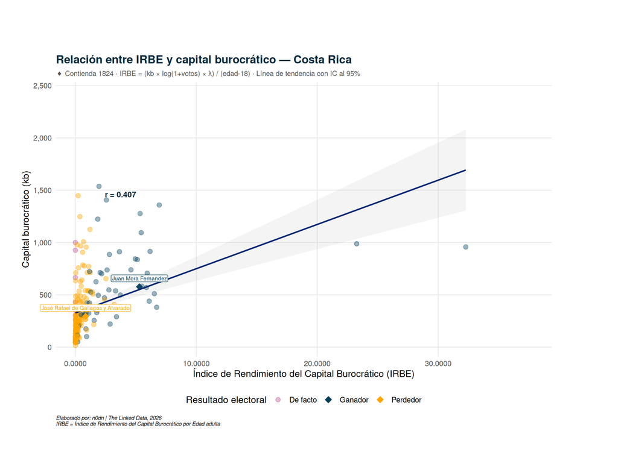

Relación entre IRBE y capital burocrático — Costa Rica

En la contienda de 1824, el candidato con mayor IRBE fue **Juan Mora Fernandez** con un valor de **5.2963**, superando la media de la contienda (**3.0706**), lo que indica una conversión eficiente de su trayectoria burocrática en respaldo electoral.

Un IRBE elevado indica que el candidato logra maximizar su rendimiento electoral por unidad de capital burocrático acumulado durante su vida adulta. Esto puede deberse a: - **Alta eficiencia burocrática**: experiencia concentrada en cargos estratégicos - **Alta eficiencia electoral**: capacidad de traducir experiencia en votos - **Alta combinación de ambos**: perfil hegemónico

## 8 Conclusiones

Los principales indicadores construidos revelan una estructura de poder significativamente concentrada. Los 2 candidatos acumulan un total de 872 kb, con una media de 436 kb que se ubica **por debajo** de la media histórica del país (485 kb), y un Índice de Herfindahl-Hirschman (HHI) de 0.5523 que confirma dicha concentración.

La composición del kb muestra que, históricamente, el 87.24% proviene de cargos dentro del ApE, mientras que en esta contienda dicha proporción alcanza el 81.24%, lo que sugiere un **menor control del ApE** respecto al promedio histórico.

El candidato con mayor acumulación dentro del ApE es **Juan Mora Fernandez** (517 kb), destacando el nivel Para, mientras que fuera del ApE el líder es **José Rafael de Gallegos y Alvarado** (80 kb), predominando el nivel Exa.

Los tres candidatos con mayor kb concentran el 100% del total, con una brecha del 48.9% entre el primero y el segundo lugar, lo que **representa una ventaja sustancial** del líder.

El ganador de la contienda **se ubica en la posición1** del ranking, con un kb equivalente a 1.3 veces la media.

El análisis del IRBE introduce una dimensión dinámica al evaluar la eficiencia con que los candidatos transforman su trayectoria institucional en respaldo electoral. En la contienda estudiada, el candidato con mayor IRBE es **Juan Mora Fernandez** con un valor de 5.2963, **superior** a la media de la contienda (3.0706), lo que indica una conversión eficiente de su trayectoria burocrática.

La evolución histórica del kb promedio en Costa Rica muestra una insuficientes contiendas previas para calcular tendencia, y la contienda de 1824 se ubica en la posición 28 de 58 contiendas registradas (48.3° percentil).

## 9 Referencias

Balmori, D., Voss, S. F., & Wortman, M. L. (1990). *Las alianzas de familias y la formación del país en América Latina*. Fondo de Cultura Económica.

Bambirra, V. (1978). *El Capitalismo Dependiente Latinoamericano*. Siglo Veintiuno Editores.

Barabási, A.-L., & Albert, R. (1999). Emergence of Scaling in Random Networks. *Science*, *286*(5439), 509-512.

Barrat, A., Barthélemy, M., Pastor-Satorras, R., & Vespignani, A. (2004). The Architecture of Complex Weighted Networks. *Proceedings of the National Academy of Sciences*, *101*(11), 3747-3752.

Basave Kunhardt, J. (1997). *Los grupos de capital financiero en México (1974-1995)*. Ed. el Caballito.

Beyhaut, G., & Beyhaut, H. (Eds.). (1985). *América Latina*. Siglo Veintiuno Editores.

Collier, S., & Sater, W. F. (1999). *Historia de Chile, 1808-1994*. Cambridge University Press.

Jessop, B. (2016). *The State. Past, Present and Future*. Polity Press.

Poulantzas, N. A. (1991). *Estado, poder y socialismo*. Siglo Veintiuno.

Ravasz, E., & Barabasi, A.-L. (2002). Hierarchical Organization in Complex Networks. *Physical Review E*, *67*(2).

Ribeiro, D. (1977). *El Dilema de América Latina. Estructuras de Poder y Fuerzas Insurgentes*. Siglo Veintiuno Editores.